# Rain and Drought Records Collection

- Show All Code
- Hide All Code
- View Source

10-Year Historical Records

Author

Antigravity Coding Assistant

Published

```python
import sys
sys.path.append('.')
from rainDrought.config import get_config
config = get_config()
```

```python
from rainDrought.visualizations import show_collect_data_intro
show_collect_data_intro(config)
```

# Introduction

This document contains Python code to programmatically retrieve, process, and store 10-year historical climate records for: 1. **Weekly Drought Monitor records** for Oglala Lakota County (FIPS 46102), South Dakota. 1. **Weekly Drought Monitor records** for Todd County (FIPS 46121), South Dakota.

2. **Daily Precipitation records** for the State of South Dakota (state-wide mean).

The collected datasets are saved to the `data/` directory.

> [!NOTE] **Active Region Configuration**: Default configured for **South Dakota** (precipitation) and counties: Oglala Lakota County (Pine Ridge), Todd County (Rosebud). To customize these locations, copy the layout from `config.csv.default` (or the example from `config.csv.example`) into a new `config.csv` file and re-run.

# Data Sources & Citations

1. **U.S. Drought Monitor (USDM)**
   - **Source**: National Drought Mitigation Center (NDMC), University of Nebraska-Lincoln, USDA, and NOAA.
   - **Description**: Weekly reports of drought severity classifications (None, D0-D4) indicating the percentage of area affected.
   - **Data Access**: Retrieved via the USDM REST Data Services API: `https://usdmdataservices.unl.edu/api/`.
   - **Citation**: > U.S. Drought Monitor. (2026). *U.S. Drought Monitor data archives*. National Drought Mitigation Center. Retrieved from https://droughtmonitor.unl.edu/
2. **Applied Climate Information System (ACIS)**
   - **Source**: NOAA Regional Climate Centers (RCCs).
   - **Description**: Daily precipitation observations aggregated and interpolated across the state of South Dakota, computed as a statewide mean.
   - **Data Access**: Retrieved via the ACIS GridData API: `https://data.rcc-acis.org/GridData`.
   - **Citation**: > Applied Climate Information System (ACIS). (2026). *Gridded Daily Precipitation (NRCC Interpolated Grid)*. NOAA Regional Climate Centers. Retrieved from https://www.rcc-acis.org/

# Data Collection Pipeline

The following Python block dynamically computes the date range for the past 10 years and calls the respective APIs to fetch and store the records.

```python
from rainDrought.data_pipeline import run_pipeline
run_pipeline(config)
```

```
Active State: South Dakota (sd)
Active Counties:
  - Oglala Lakota County (FIPS: 46102, Label: Pine Ridge)
  - Todd County (FIPS: 46121, Label: Rosebud)

Timeframe: 2016-08-27 to 2026-08-27
Querying USDM API for Oglala Lakota County...
-> Successfully saved weekly drought data to data/oglala_lakota_drought_weekly.csv
Querying USDM API for Todd County...
-> Successfully saved weekly drought data to data/todd_drought_weekly.csv
Querying ACIS GridData API...
-> Successfully saved daily precipitation data to data/south_dakota_precipitation_daily.csv
```

# Data Previews & Summaries

Let’s load the saved datasets to verify their content and print summary statistics.

```python
from rainDrought.data_pipeline import show_summaries
show_summaries(config)
```

## U.S. Drought Monitor Data Summary (Oglala Lakota County)

**Weekly USDM records:** 523

|  | ValidStart | County | None | D0 | D1 | D2 | D3 | D4 |
| --- | --- | --- | --- | --- | --- | --- | --- | --- |
| 518 | 2026-07-28 | Oglala Lakota County | 0.0 | 100.0 | 100.0 | 100.0 | 33.84 | 0.0 |
| 519 | 2026-08-04 | Oglala Lakota County | 0.0 | 100.0 | 100.0 | 100.0 | 43.18 | 0.0 |
| 520 | 2026-08-11 | Oglala Lakota County | 0.0 | 100.0 | 100.0 | 100.0 | 43.18 | 0.0 |
| 521 | 2026-08-18 | Oglala Lakota County | 0.0 | 100.0 | 100.0 | 100.0 | 43.18 | 0.0 |
| 522 | 2026-08-25 | Oglala Lakota County | 0.0 | 100.0 | 100.0 | 100.0 | 43.18 | 0.0 |

### Oglala Lakota County Drought Summary Stats

|  | None | D0 | D1 | D2 | D3 | D4 |
| --- | --- | --- | --- | --- | --- | --- |
| count | 523.000000 | 523.000000 | 523.000000 | 523.000000 | 523.000000 | 523.0 |
| mean | 34.449675 | 65.550325 | 47.576922 | 18.856979 | 5.238126 | 0.0 |
| std | 46.167434 | 46.167434 | 46.299453 | 33.810416 | 17.039506 | 0.0 |
| min | 0.000000 | 0.000000 | 0.000000 | 0.000000 | 0.000000 | 0.0 |
| 25% | 0.000000 | 0.000000 | 0.000000 | 0.000000 | 0.000000 | 0.0 |
| 50% | 0.000000 | 100.000000 | 42.270000 | 0.000000 | 0.000000 | 0.0 |
| 75% | 100.000000 | 100.000000 | 100.000000 | 17.450000 | 0.000000 | 0.0 |
| max | 100.000000 | 100.000000 | 100.000000 | 100.000000 | 97.570000 | 0.0 |

## U.S. Drought Monitor Data Summary (Todd County)

**Weekly USDM records:** 523

|  | ValidStart | County | None | D0 | D1 | D2 | D3 | D4 |
| --- | --- | --- | --- | --- | --- | --- | --- | --- |
| 518 | 2026-07-28 | Todd County | 0.0 | 100.0 | 100.00 | 0.0 | 0.0 | 0.0 |
| 519 | 2026-08-04 | Todd County | 0.0 | 100.0 | 100.00 | 0.0 | 0.0 | 0.0 |
| 520 | 2026-08-11 | Todd County | 0.0 | 100.0 | 99.06 | 0.0 | 0.0 | 0.0 |
| 521 | 2026-08-18 | Todd County | 0.0 | 100.0 | 98.97 | 0.0 | 0.0 | 0.0 |
| 522 | 2026-08-25 | Todd County | 0.0 | 100.0 | 66.20 | 0.0 | 0.0 | 0.0 |

### Todd County Drought Summary Stats

|  | None | D0 | D1 | D2 | D3 | D4 |
| --- | --- | --- | --- | --- | --- | --- |
| count | 523.000000 | 523.000000 | 523.000000 | 523.000000 | 523.000000 | 523.0 |
| mean | 43.186788 | 56.813212 | 29.544226 | 11.545315 | 2.528470 | 0.0 |
| std | 46.902388 | 46.902388 | 42.076676 | 29.324221 | 12.088991 | 0.0 |
| min | 0.000000 | 0.000000 | 0.000000 | 0.000000 | 0.000000 | 0.0 |
| 25% | 0.000000 | 0.000000 | 0.000000 | 0.000000 | 0.000000 | 0.0 |
| 50% | 0.000000 | 100.000000 | 0.000000 | 0.000000 | 0.000000 | 0.0 |
| 75% | 100.000000 | 100.000000 | 75.520000 | 0.000000 | 0.000000 | 0.0 |
| max | 100.000000 | 100.000000 | 100.000000 | 100.000000 | 79.050000 | 0.0 |

## Daily Precipitation Data Summary (South Dakota)

**Number of daily precipitation records:** 3653

|  | date | precipitation_inches |
| --- | --- | --- |
| 3648 | 2026-08-23 | 0.067627 |
| 3649 | 2026-08-24 | 0.075267 |
| 3650 | 2026-08-25 | 0.112057 |
| 3651 | 2026-08-26 | 0.000299 |
| 3652 | 2026-08-27 | NaN |

### Precipitation Summary Stats

```
count    3652.000000
mean        0.059764
std         0.124284
min         0.000000
25%         0.000664
50%         0.008864
75%         0.056090
max         1.374540
Name: precipitation_inches, dtype: float64
```

# Visualizations

Let’s visualize the trends over the 10-year period.

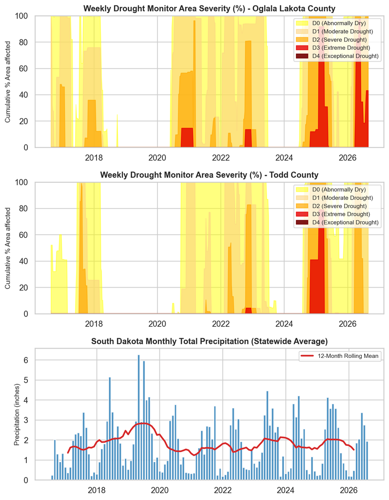

```python
from rainDrought.visualizations import plot_matplotlib_trends
plot_matplotlib_trends(config)
```